# Statistics 133 Project Report:Determinants of Home Price and Its Fluctuation over Time in California

Group 14(A+): Hong Jabbari,Yangyang Li,Zhiyue Hu,and Renjun Zhu

May 6th, 2016

*Source file* ⇒ Project_Report.Rmd

## 1. Introduction

The idea of having a home dates back 12 to 15,000 years. Home, brings people closer; home, generates family; home, sweet home. As soon as ownership of land or property developed, houses quickly became commodities that had their own market value. Purchasing a home was, is, and will be the dream for many centuries in cultures across the globe. Home is not just a place of shelter, but more a place for you to experience life and leave traces of that life for future generations. Throughout modern history, the topic of affordable housing has remained a significant force in society. From individual concerns to the moving curve of global economy, home price is one of the most important indicators to measure the growing wealth in a society. Many issues are related to real estate, such as the housing bubble that triggered the financial crisis in 2008. Therefore, it is worthwhile to take a close look at the determinants of home prices and their fluctuation over time.

California is located on the West coast of the United States and crosses a wide latitude, spanning some of the most pleasant climates. It comes as no surprise that it attracts people from so many different cultures to settle down, and contains some of the most expensive residential areas for home buyers. Thus, California can be used as a suitable model from which to examine the determinants of home prices on a regional level over time.

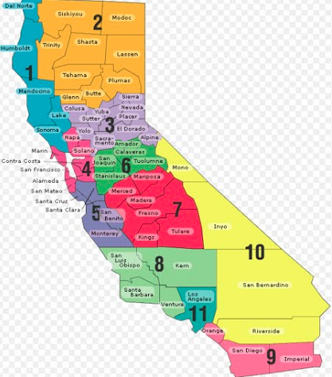

## 2.Data Resource:

Web searching allows us to collect huge data from 1996 to present, and our source came from different websites, namely zillow.com, a database website which provides home prices; labormarketinfo.edu.ca.gov, where gives us detailed information about unemployment rate; dof.ca.gov, a government website which updates the city population in California each year; and cde.ca.gov, an official website run by California government to report the API score of each public high schools. We are aiming to get data for these three determinants from 2010 to 2014 because the year before and around 2008 have been widely studied by other researcher and scholars due to the financial crisis happened in 2008. In order to avoid the redundancy, we are more interested in the analysis of recent year home price after the depression in 2008. To see the tendency of each determinant versus home price, we put all the 5 years together to get the graph for each determinant. We use the same set of data and do further cleaning for the region dividing graph. However, to make the map, the animation, and the graph of home price fluctuation time series, zillow.com again provides us data from 1996 to present.

## 3. Analysis and Visualization:

### 3.1 Determinant of Home Price: Population, API and Unemployment Rate

In order to compare the effectiveness of these three determinants, we have to normalize each determinant by the idea of Z value: by applying our knowledge from statistics class, we use below formula to make such normalization; hence, we can compare them in the same graph:
$$z=\frac{x_{ij}-\bar{x_{i}}}{\sqrt{\frac{\sum_{i}\left (x _{ij} -\bar{x_{i}}\right )^{2}}{\left ( n-1 \right )}}}$$
Note: i = each determinant (Population, API, and Unemployment Rate) j = each city

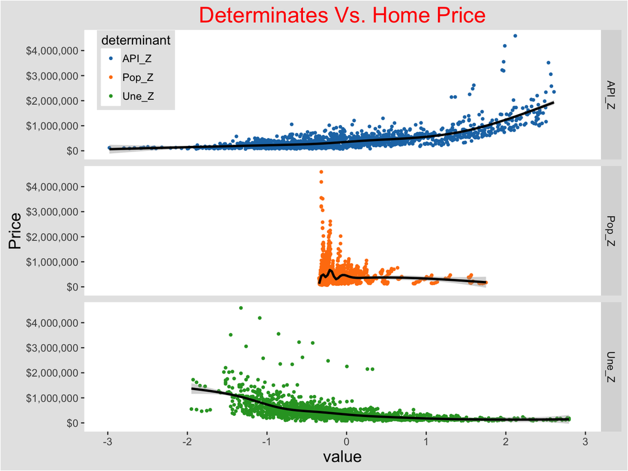

Recall our naive guess such that cities with large population tend to have higher home price. To test this, we plotted 320 cities in 5 years with their population and average home prices. Surprisingly, the correlation coefficient of the regression r = -0.01439502 is a negative value and very closed to zero, which shows that the home price is almost not related to Population. Setting up 95 percent confidence interval, we applying t-test with 1559 degree of freedom, and get the p-value = 0.5698. This large p-value (greater than 0.5) will reject our hypothesis that Population is a determinant, which affects home price significantly. In addition, even though the regression lines within these 5 years are very stable, by comparing 2010 through 2014 y-axis (Home Price), observe the fact of home price shifting up each year is quite obvious. This makes sense because our living standard is moving up, and the inflation rate for currency is still on-going and we didn’t consider the inflation rate for home price yet when collecting data.

The first panel has showed a strong correlation with r = 0.6908296 between High School API Score and home price, which respond our initial hypothesis that high school with higher academic performance tend to have higher housing around them. Same t-test applied here with 1559 degree of freedom, and we also get the same p-value < 2.2e-16 as determinant unemployment rate. Comparing such small p-value with 95 percent of confident interval rate, which supports our initial claim. Despite the fact that not every homeowner around school district carries children in the house, having an house near school district can alternately become an investment for them to rent out. This argument can explain that within our 5 consecutive years, the slope of each line become steeper and steeper, so more and more people like to invest their money on school district, and the tendency of home price rise higher as time goes by.

The third panel of unemployment rate versus home price below echo our claim that high unemployment rate will negatively affect home price. There is a -0.5147542 correlation between unemployment rate and home price. Looking at P-value, less than 2.2e-16 indicates a significant negative correlation between home price. History has shown that most homeowners purchase house with a stable job because they need the monthly salary to support the mortgage. However, in recent year, there is also a fair amount of the homeowners use all cash to pay for the total amount at once, and of course this group is not bounded by job security. It would be normal to have such an okay correlation value of -.5 rather than a strongly negative correlation such as values closer to -1. Moreover, within 2010 to 2014 these consecutive years, the lines are tilted up gradually. Simply by looking the intersection of each lines with zero value of home price. Notice that not just the unemployment rate is getting closer towards smaller value in order to reaching zero value of home price, all the dots in each plot have been shifted inner towards within 5 % of unemployment rate, and the tails are getting diminished. Such a shift shows that our economy environment is getting better each year after the recession of 2008.

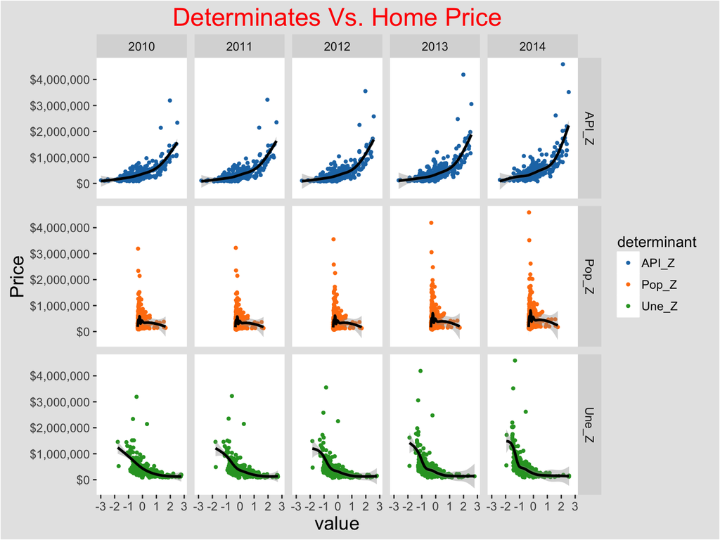

## 3.2 Comparison of North, Central, and South

### 3.2.1 Graphs in Different Year

In terms of comparing three regions(North, Central, and South) within California. We plot a violin graph to show the variation of home prices by region. By looking at the shapes of each “violin” along time, the graph below has suggested that the “fat” shape of Central California in the bottom part of its “violin” stays pretty constant below 200,000 dollars, and also there is a small wave at around 500,000; however, after 2011, more and more over million dollars houses appear, and its “violin” shape started to grow bigger and shift up a little, especially the year in 2014. For Northern California, the “violin” shape shrank a little bit at 2012 and started to grow back the year after, but roughly the mean value of home prices is at around 250,000 and gradually narrow down as the price goes up. Also, besides the vertical growing, it also increases the size of its home price at any level horizontally, Finally, Southern California inherits about the same shape over time, it also has mean value higher than the other two regions with around 300,000 dollars and beyond. At year 2014, the quantity of home buyers corresponding to home price at each level below 2 million has increased significantly. Moreover, the “leaf” shape of Southern California indicates its little variation of home price compared to other regions.

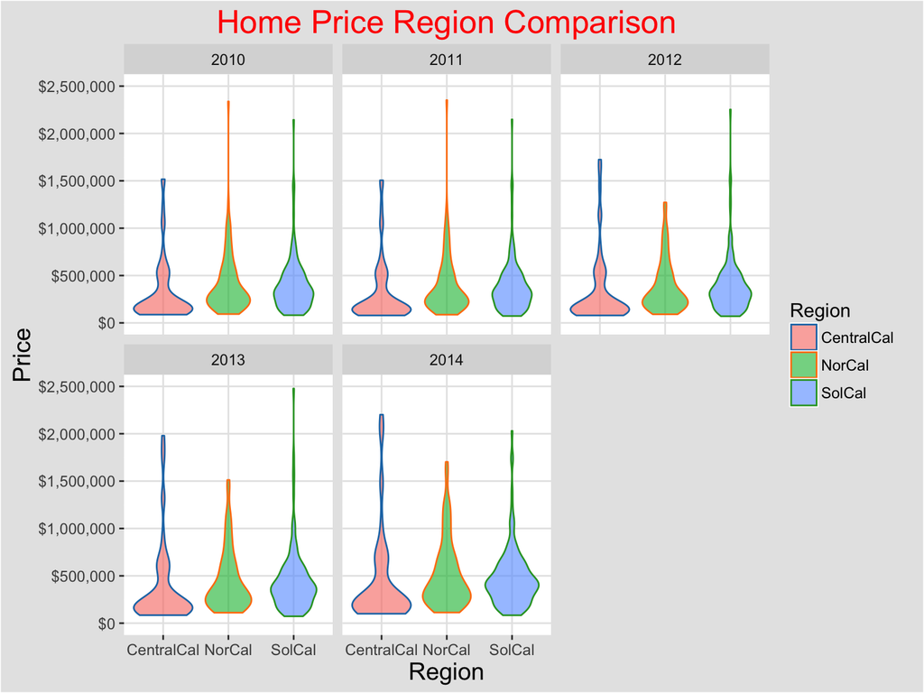

### 3.2.2 Graph as a Whole (disregard year)

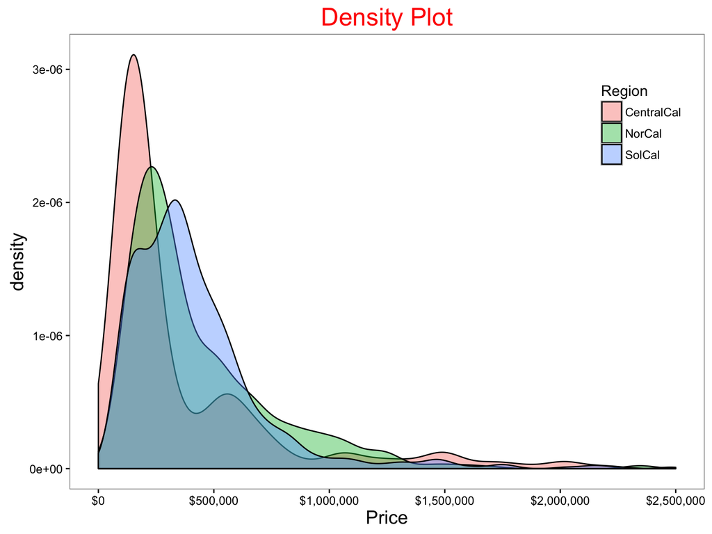

## 3.3 From the Coast to Inland

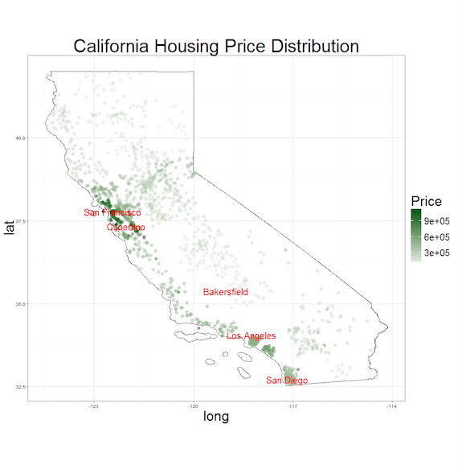

## 3.4 Over One Million Dollars Home:

In order to represent the dynamic movement of home price within regions, we collect data from 1996 to 2016, and filter out the the location(latitude and longitude) of houses with price over 1 million dollars, and organized in a kml.file which will use google earth software to present during our 6 minutes slides presentation during RRR week. (google earth: May, 4th & Code: Appendix) In 1996, most cities with an average price of more than 1 million are located in Southern California, for example, the infamous Rancho Santa Fe and Beverly Hills. The animation shows that within these 20 years, started from Southern California, moving up along the coast, more and more over million home was built. Especially in bay area, more precisely in the south bay along Silicon Valley, million dollars houses are piled. We analyzed that many big companies such as Apple, Google, ebay, and Yahoo set their headquarter in this region. Many of those are high technology companies with a great market value, and a well-known fact is that 21st century is an era of technology, so no surprising that tech-related jobs with high-paying salary are always in demand. With higher income and opportunities in this region, the home price collectively over million dollars will not be considered as a legend. Although generally the pins keep appearing, there is, however, a significant wave of disappearing of pins from 2008 to 2011, which indicate the effect of financial crisis on housing prices.(Partial Animation)

[figure not shown]

## 3.5 In a time frame

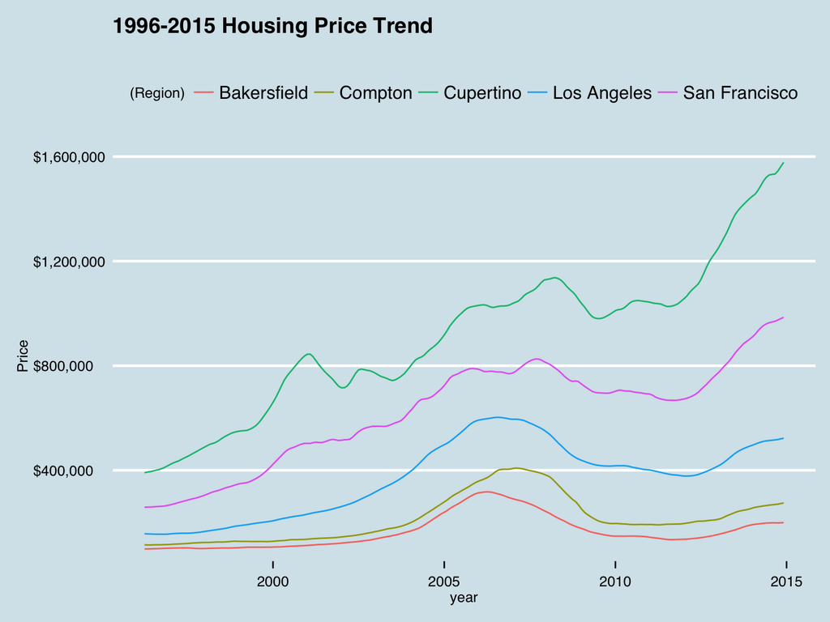

## 4. Conclusion:

Through the collaboration of this group project, we found there is almost no correlation between home price and city population. While, there is a strong correlation with high school API score, and a moderate level of negative correlation with unemployment rate. Along the way of our analysis of these two determinants, we also discovered the economic growth of our nation within the 5 years after the recession began in 2008. In addition to demonstrating conclusions about our several hypotheses, we also visualized the variation of home price over a span of 5 years across the map of California, divided into North, Central, and South regions. The map of California home price highlights the coastline home value compared to inland, and also outlines the general region of financial centers inside of California. Moveover, the animation using google earth pinpoints the aggregation of wealth corresponding to technological intelligence. Finally, the home price fluctuation graph, with the five selected cities, depicts the significant impact on home prices due to some unfortunate stressors in the recent history.

Our study of the determinants of home price and its fluctuation in California only scratches the surface of this subject, no matter which period of time we selected. With respect to the fluctuation of home prices curve, we only made cursory descriptions of the change. Beyond the skills that we applied from our knowledge of statistics, there are also other cross-disciplinary perspectives, which when combined can provide a wider frame of reference to investigate this economic phenomenon.

# Appendix:

## Table 1:(5 years data) serve as our basis table, generate plot 1 and plot 2

```r
table1 <- read.csv("/Users/renjunzhu/Downloads/R Study/POP+UN+PRI+API.CSV")
head(table1, 10)
```

```
##     X     Area Year      API Population Unemployment_Rate  Price
## 1   1   Albany 2010 886.0000      18539               7.2 558500
## 2   2   Albany 2011 896.8000      18343               6.6 540000
## 3   3   Albany 2012 901.2000      18481               5.7 556775
## 4   4   Albany 2013 906.0000      18483               4.7 666358
## 5   5   Albany 2014 901.8000      18457               3.8 721783
## 6   6 Alhambra 2010 800.9444      83089               8.3 456200
## 7   7 Alhambra 2011 809.6667      83362               8.1 443158
## 8   8 Alhambra 2012 810.8333      83841               7.2 429733
## 9   9 Alhambra 2013 826.0000      84390               6.4 474442
## 10 10 Alhambra 2014 826.7222      84736               5.4 532250
```

## Table 2:(5 years data) add on top of table 1, generate plot 3 and plot 4

```r
table2 <- read.csv("/Users/renjunzhu/Downloads/R Study/joinfinal.csv")
head(table2, 10)
```

```
##     X CountyName Region       Area Year      API Population
## 1   1    Alameda NorCal   Piedmont 2010 938.4000      10667
## 2   2    Alameda NorCal    Hayward 2012 727.0625     147090
## 3   3    Alameda NorCal   Berkeley 2013 839.2000     116118
## 4   4    Alameda NorCal   Berkeley 2012 831.0667     114807
## 5   5    Alameda NorCal   Piedmont 2011 942.8000      10708
## 6   6    Alameda NorCal Union City 2014 774.0000      72109
## 7   7    Alameda NorCal  Livermore 2014 842.4000      84815
## 8   8    Alameda NorCal   Berkeley 2011 814.0667     113918
## 9   9    Alameda NorCal    Hayward 2010 703.3750     144186
## 10 10    Alameda NorCal    Hayward 2011 718.8750     145090
##    Unemployment_Rate   Price
## 1                6.3 1258150
## 2               12.0  279092
## 3                5.8  769183
## 4                7.0  653592
## 5                5.8 1209692
## 6                5.2  583392
## 7                4.0  604542
## 8                8.2  618150
## 9               14.9  288500
## 10              13.8  272908
```

## Table 3-4:(10 years data) generate plot 5(map) and google earth animation.

### table 3(bbtable): table 3 is the raw data->bbtable is after first layer cleanning.

```r
table3 <- read.csv("/Users/renjunzhu/Downloads/R Study/City_Zhvi_AllHomes.csv")
head(bbtable , 10)
```

```
##           Region       Year  Price       year
## 1    Los Angeles 1996.04.01 157300 1996-04-01
## 2  San Francisco 1996.04.01 258700 1996-04-01
## 3    Bakersfield 1996.04.01  98900 1996-04-01
## 4        Compton 1996.04.01 114900 1996-04-01
## 5      Cupertino 1996.04.01 390900 1996-04-01
## 6    Los Angeles 1996.05.01 156800 1996-05-01
## 7  San Francisco 1996.05.01 259100 1996-05-01
## 8    Bakersfield 1996.05.01  99300 1996-05-01
## 9        Compton 1996.05.01 114400 1996-05-01
## 10     Cupertino 1996.05.01 393300 1996-05-01
```

### table 4:

```r
table4<- read.csv("/Users/renjunzhu/Downloads/R Study/cityloc.csv")
head(table4, 10)
```

```
##    zip_code latitude longitude       city state    county
## 1       501 40.92233 -72.63708 Holtsville    NY   Suffolk
## 2       544 40.92233 -72.63708 Holtsville    NY   Suffolk
## 3       601 18.16527 -66.72258   Adjuntas    PR  Adjuntas
## 4       602 18.39310 -67.18095     Aguada    PR    Aguada
## 5       603 18.45591 -67.14578  Aguadilla    PR Aguadilla
## 6       604 18.49352 -67.13588  Aguadilla    PR Aguadilla
## 7       605 18.46516 -67.14149  Aguadilla    PR Aguadilla
## 8       606 18.17295 -66.94411    Maricao    PR   Maricao
## 9       610 18.28869 -67.13970     Anasco    PR    Anasco
## 10      611 18.27953 -66.80217    Angeles    PR    Utuado
```

## R Code:

### Table 1:

```r
## After download data from zillow.com for house price, calculate the mean value of home price from 2010 to 2014

multifam <- read.csv("City_Zhvi_AllHomes.csv")
multifamca <- multifam %>%
  filter (State=="CA")  %>%
  select(RegionName, X2010.11:X2014.12) %>%
mutate(avg14=round(1/12*(X2014.01+X2014.02+X2014.03+X2014.04+X2014.05+X2014.06+X2014.07+X2014.08+X2014.09+X2014.10+X2014.11+X2014.12)),
avg13=round(1/12*(X2013.01+X2013.02+X2013.03+X2013.04+X2013.05+X2013.06+X2013.07+X2012.08+X2013.09+X2013.10+X2013.11+X2013.12)),     avg12=round(1/12*(X2012.01+X2012.02+X2012.03+X2012.04+X2012.05+X2012.06+X2012.07+X2012.08+X2012.09+X2012.10+X2012.11+X2012.12)),
avg11=round(1/12*(X2011.01+X2011.02+X2011.03+X2011.04+X2011.05+X2011.06+X2011.07+X2011.08+X2011.09+X2011.10+X2011.11+X2011.12)),
avg10=round(1/2*(X2010.11+X2010.12)))

### make a narrow table to get ready for joining with other determinants

multifamcamean <- multifamca %>%
select ( RegionName,avg14:avg10) %>%
arrange(RegionName) %>% gather(key=Year,value=pricemean,avg14,avg13,avg12,avg11,avg10)

### change the structure of character to numeric

subs = function(x){
  for (i in 1:length(x)){
    if (grepl("avg14", x[i])){
      x[i] = 2014
    }
    else if (grepl("avg13", x[i])){
      x[i] = 2013
    }
    else if(grepl("avg12", x[i])){
      x[i] = 2012
    }
    else if(grepl("avg11", x[i])){
      x[i] = 2011
    }
    else if(grepl("avg10", x[i])){
      x[i] = 2010
    }
  }
  return(x)
}
multifamcamean$Year = subs(multifamcamean$Year)
str(multifamcamean)

## After download data from labormarketinfo.edu.ca.gov for unemployment rate

UR <-read.csv("/Users/renjunzhu/Downloads/R Study/1014UR.csv")
UR1 <- UR %>%
  filter(!grepl("CDP",Area))%>%
  mutate(Area=gsub(" city$| town$","",Area))%>%
  select(-Period,-Adjusted,-Preliminary)
UR1$Year <- as.character(UR1$Year)
str(UR1)

## Join Home Price with determinant Unemployment rate into one table

colnames(multifamcamean)[colnames(multifamcamean)=="RegionName"] <- "Area"
Right <- multifamcamean %>%
select(Area,Price,Year) %>%
group_by(Area) %>%
arrange(Area)
join<- merge(UR1,Right,all=FALSE)

## After download data from dof.ca.gov for population

pop <-read.csv("/Users/renjunzhu/Downloads/R Study/1015population.csv")
population <- pop %>%
select(COUNTY.CITY,X4.1.10:X1.1.14)
temp = read.csv("1015population.csv", header=TRUE, sep=",")
subs = function(x){
  for (i in 1:length(x)){
    if (grepl("avg10", x[i])){
      x[i] = 2010
    }
    else if (grepl("avg11", x[i])){
      x[i] = 2011
    }
    else if(grepl("avg12", x[i])){
      x[i] = 2012
    }
    else if(grepl("avg13", x[i])){
      x[i] = 2013
    }
    else if(grepl("avg14", x[i])){
      x[i] = 2014
    }
  }
  return(x)
}
colnames(temp) = c("City", "avg10", "avg11", "avg12", "avg13", "avg14")
temp = na.omit(temp)

### In the original csv file, the population data is a factor, needs to "numericalize" it.

temp$avg10 = as.numeric(gsub(",", "", temp$avg10))
temp$avg11 = as.numeric(gsub(",", "", temp$avg11))
temp$avg12 = as.numeric(gsub(",", "", temp$avg12))
temp$avg13 = as.numeric(gsub(",", "", temp$avg13))
temp$avg14 = as.numeric(gsub(",", "", temp$avg14))
temp2 = temp %>%
select(City, avg10, avg11, avg12, avg13, avg14)
Population = temp2 %>%
gather(Year, Population, avg10:avg14)
Population$Year = subs(Population$Year)
join2 <- join %>%
group_by(Area) %>%
arrange(Area)
population2 <- Population %>%
group_by(Area) %>%
arrange(Area)
join3 <- merge(population2,join2,all=FALSE)
write.csv(join3,file="POP+UN+PRI.csv")

## After download data from cde.ca.gov for high school API score.

### Cut special schools, such as deaf schools, continuation schools, regional occupational program as those are public high schools that can be accessed by all cities schools and thus are directly under the management of County office of education, not under any specific city school district.

temp = read.dbf("14avgdb.dbf", as.is = FALSE)
temp2 = temp %>%
select(sname, cname, dname, api11, api12, api13)
delete_na = function(x){
  cutlist = c()
  for (i in 1:nrow(x)){
    for(k in 4:6){
    if (is.na(x[i,k])){
      cutlist = c(cutlist, i)}
    }
  }
  return(cutlist)
}
cutlist = delete_na(temp2)
temp3 = temp2[-cutlist,] #Cut School that does not have an API score
tempAPI = temp3 %>%
filter(grepl("City|Unified|Union|Elementary|District", dname)) %>%
na.omit()

### Some schools are missing data on 2010 and thus marked as "B".

temp = read.dbf("api10gdb.dbf", as.is = FALSE)
temp2 = temp %>%
select(SNAME, CNAME, DNAME, API09, API10)
temp3 = temp2 %>%
na.omit()
tempAPI2 = temp3 %>%
filter(grepl("City|Unified|Union|Elementary|District", DNAME))
colnames(tempAPI2) = c("sname", "cname", "dname", "api09", "api10")
tempAPI2 = tempAPI2[!grepl("B|C", tempAPI2$api09),]
extractcombine = function(x){
  foo = data.frame(dname=c(),
                 city=c(),
                 cname=c())
  for (i in 1:length(x)){
    tablelist = readHTMLTable(x[i])
    table = tablelist[[2]]
    colnames(table) = c("dname", "city", "cname")
    foo = rbind(foo, table)
  }
  return(foo)
}
page1 = "http://www.greatschools.org/schools/districts/California/CA"
page2 = "http://www.greatschools.org/schools/districts/California/CA/2"
page3 = "http://www.greatschools.org/schools/districts/California/CA/3"
page4 = "http://www.greatschools.org/schools/districts/California/CA/4"
pagelist = c(page1, page2, page3, page4)
tempDistrict = extractcombine(pagelist)

tempDistrict$dname=gsub("[[:blank:]]School[[:blank:]]District","",tempDistrict$dname)
APItabletemp = inner_join(tempAPI, tempDistrict, by = c("dname", "cname"))
APItable = APItabletemp %>%
inner_join(tempAPI2, by = c("dname", "cname", "sname")) %>%
na.omit()
APItable$api09 = as.numeric(as.character(APItable$api09))
APItable$api10 = as.numeric(as.character(APItable$api10))
APItable$api11 = as.numeric(as.character(APItable$api11))
APItable$api12 = as.numeric(as.character(APItable$api12))
APItable$api13 = as.numeric(as.character(APItable$api13))

### Some of the data are numeric while others are characteristic, thus need to be converted in this form.

API_almost = APItable %>%
group_by(city) %>%
mutate(avg14 = mean(api13)) %>%
mutate(avg13 = mean(api12)) %>%
mutate(avg12 = mean(api11)) %>%
mutate(avg11 = mean(api10)) %>%
mutate(avg10 = mean(api09))
API = API_almost[!duplicated(API_almost["city"]), ] %>%
select(city, avg10, avg11, avg12, avg13, avg14)

APIG = API %>%
gather(Year, API, avg10:avg14)
subs = function(x){
  for (i in 1:length(x)){
    if (grepl("avg10", x[i])){
      x[i] = 2010
    }
    else if (grepl("avg11", x[i])){
      x[i] = 2011
    }
    else if(grepl("avg12", x[i])){
      x[i] = 2012
    }
    else if(grepl("avg13", x[i])){
      x[i] = 2013
    }
    else if(grepl("avg14", x[i])){
      x[i] = 2014
    }
  }
  return(x)
}
APIG$Year = subs(APIG$Year)
colnames(APIG)[colnames(APIG)=="city"] <- "Area"

### Due to the limitation of source, we need to get 2015 data seperately

APIG2 <- APIG %>%
group_by(Area) %>%
arrange(Area)

## Join table for table 1:

join4 <- merge(APIG2,join3,all=FALSE)
write.csv(join4,file="POP+UN+PRI+API.CSV")
```

### Table 2:

```r
## Making three vectors represent the regions, which contain the counties corresponding to the map above.

NorCal <- c("Humboldt","Mendocino","Lake","Sonoma","Siskiyou","Modoc",
"Trinity","Shasta","Lassen","Tehama","Plumas","Butte","Glenn","Colusa","Yuba", "Sutter","Yolo","Sierra","Nevada","Placer","El Dorado","Alpine","Sacramento","Napa","Solano","Contra Costa","San Francisco",
"Alameda","San Mateo","Marin","Alaleda","San Benito","Monterey")

CentralCal <- c("Santa Cruz","Santa Clara","San Joaquin","Stanislaus",
"Amador","Calaveras","Tuolumne","Mono","Inyo","Mariposa","Merced","Madera","Fresno","Kings","Tulare")

SolCal <- c("San Luis Obispo","Kern","Santa Barbara","Ventura","Los Angeles",
"San Bernardino","Riverside","Orange","San Diego","Imperial")

## Putting vectors into data frame.

CountyName <- c(NorCal, CentralCal, SolCal)
Region <- c(rep("NorCal",33), rep("CentralCal", 15), rep("SolCal",10))
regiondf <- data.frame(CountyName,Region)

## Join with table 1

joinfinal <- merge(regiondf,join4,all=FALSE)
write.csv(joinfinal,file="joinfinal.csv")
```

## Plot (page 4-11)

## Plot 1-2

### dot-linear plot:

```r
### Data Cleaning: apply formula and use gather function

table1 <- read.csv("/Users/renjunzhu/Downloads/R Study/POP+UN+PRI+API.CSV")
A<-mean(table1$API)
sdA<-sd(table1$API)
B<-mean(table1$Population)
sdB<-sd(table1$Population)
C<-mean(table1$Unemployment_Rate)
sdC<-sd(table1$Unemployment_Rate)
table1<-table1%>%mutate(API_Z=(API-A)/sdA, Pop_Z=(Population-B)/sdB,Une_Z=(Unemployment_Rate-C)/sdC)
```

### Plot1: Determinants Vs. Home Price (page 4)

```r
new2<-table1 %>% select(Year, API_Z, Pop_Z, Une_Z, Price)
New2<-new2 %>% gather(key=determinant, value=value, API_Z, Pop_Z, Une_Z)
ggplot(New2, aes(x=value,y=Price))+geom_point(aes(color=determinant),size=0.9)+geom_smooth(col="black")+facet_grid(determinant~.)+labs(title="Determinates Vs. Home Price")+scale_y_continuous(labels = dollar)+scale_x_continuous(limits = c(-3,2.9))+theme_igray()+ scale_colour_tableau()+theme(plot.title=element_text(size = 20, color = "Red"),axis.title= element_text(size = 15),legend.position =c(0.1,0.9),panel.grid = element_blank())
```

### Plot2: Determinants Vs. Home Price facet by Year (page 6)

```r
new2<-table1 %>% select(Year, API_Z, Pop_Z, Une_Z, Price)
New2<-new2 %>% gather(key=determinant, value=value, API_Z, Pop_Z, Une_Z)
%>%ggplot(aes(x=value,y=Price))+geom_point(aes(color=determinant),size=0.9)+geom_smooth(col="black")+facet_grid(determinant~Year)+labs(title="Determinates Vs. Home Price")+scale_y_continuous(labels = dollar)+scale_x_continuous(limits = c(-3,2.9))+theme_igray()+ scale_colour_tableau()+theme(plot.title=element_text(size = 20, color = "Red"),axis.title= element_text(size = 15),legend.position =c(0.1,0.9),panel.grid = element_blank())

## For Analysis:

### Calculate the correlation between Population and Home Price

table1 <- read.csv("/Users/renjunzhu/Downloads/R Study/POP+UN+PRI+API.CSV")
lm.out<-lm(formula = Price ~ Population,data =table1)
summary(lm.out)
cor.test(table1$Population,table1$Price)

### Calculate the correlation between Unemployment Rate and Home Price
lm.out<-lm(formula = Price ~ Unemployment_Rate,data =table1)
summary(lm.out)
cor.test(table1$Unemployment_Rate,table1$Price)

## Calculate the correlation between API and Home Price
lm.out<-lm(formula = Price ~ API,data =table1)
summary(lm.out)
cor.test(table1$API,table1$Price)
```

## Plot 3-4: Region Graph (page 7-8)

### Plot3: violin graph (page 7)

```r
table1 <- read.csv("/Users/renjunzhu/Downloads/R Study/joinfinal.csv")%>%
group_by(Region)
p <- table1 %>%
ggplot(aes(x=Region,y=Price))+labs(title="Home Price Region Comparison")+scale_y_continuous(labels = dollar,limits = c(0,2500000))+theme_igray() +scale_colour_tableau()+geom_violin(aes(color=Region,fill=Region),alpha=0.6)+facet_wrap(~Year)+theme(axis.title= element_text(size = 15),plot.title=element_text(size = 20, color = "Red"))
p
```

### Plot 4: density graph (page 8)

```r
table1 <- read.csv("/Users/yangyangli/Desktop/joinfinal.csv")%>%
group_by(Region)
p <- table1 %>%
ggplot(aes(x=Price))+geom_density(aes(fill=Region),alpha=0.4)+labs(title="Density Plot")+scale_x_continuous(labels = dollar,limits = c(0,2500000))+theme_bw()+theme(plot.title=element_text(size = 20, color = "Red"),axis.title= element_text(size = 15),legend.position =c(0.9,0.8), panel.grid = element_blank())
p
```

## Plot 5: California Map (page 9)

```r
### Download bycounty.csv file from zillow.com

county = read.csv("bycounty.csv")
countytidy = county %>%
filter(State == "CA") %>%
select(RegionName,X2015.12) %>%
na.omit()
loc = read.csv("cityloc.csv")
locca = loc %>%
filter(state == "CA") %>%
na.omit()

#locca = locca[!duplicated(locca["county"]),]

loctidy = locca %>%
select(county, latitude, longitude)
colnames(loctidy) = c("RegionName", "lat", "long")
location = merge(countytidy, loctidy, all=TRUE) %>%
na.omit()

### getting the region of California

library(geosphere)
geo.dist = function(df) {
  require(geosphere)
  d = function(i,z){         # z[1:2] contain long, lat
    dist = rep(0,nrow(z))
    dist[i:nrow(z)] = distHaversine(z[i:nrow(z),1:2],z[i,1:2])
    return(dist)
  }
  dm = do.call(cbind,lapply(1:nrow(df),d,df))
  return(as.dist(dm))
}
loc2 = read.csv("cityloc.csv")
set.seed(420)
CA     = loc2[loc2$state=="CA",]
CA     = CA[sample(1:nrow(CA),500),] %>% na.omit()
long=CA$longitude
lat=CA$latitude
city=CA$city
df     = data.frame(long, lat, city)
d      = earth.dist(df)   # distance matrix
hc     = hclust(d)      # hierarchical clustering
df$clust = cutree(hc,k=4)

### Install many packages and apply functions inside of these packages.

install.packages("rgdal")
install.packages("maptools")
install.packages("rgeos")
install.packages("C:\\Users\\Tom\\Documents\\gpclib.tar.gz", repos = NULL, type="source")
install.packages("ez", dependencies = TRUE)
library(rgeos)
library(maptools)
library(rgdal)
library(ez)
gpclibPermit()
map.US  = readOGR(dsn=".", layer="tl_2013_us_state")
map.CA  = map.US[map.US$NAME=="California",]
map.df  = fortify(map.CA)
ggplot(map.df)+
  geom_path(aes(x=long, y=lat, group=group))+
  geom_point(data=location, aes(x=long, y=lat, color=X2015.12), size=3, alpha=0.4)+ scale_colour_gradient2( "Price", high=muted("green"))+
  coord_fixed()+
  theme_bw()+
  labs(title="California Housing Price Distribution")+
  theme(plot.title=element_text(size=40), axis.title=element_text(size=20),
axis.title.x=element_text(size=30),
axis.title.y=element_text(size=30),
legend.text=element_text(size=20),
legend.title=element_text(size=30))+
  annotate("text", y = 37.7739, x = -122.4313, label = "San Francisco", color="red", size=7)+
  annotate("text", y = 34.0522, x = -118.2437, label = "Los Angeles", color="red", size=7)+
  annotate("text", y = 32.7157, x = -117.1611, label = "San Diego", color="red", size=7)+
  annotate("text", y = 35.3744, x = -119.0187, label = "Bakersfield", color = "red", size = 7)+
  annotate("text", y = 37.3230, x = -122.0322, label = "Cupertino", color = "red", size = 7)
```

## Plot 6: Price Fluctuation Plot (page 11)

```r
### Making graph ready table and cleaning

library(lubridate)
library(ggplot2)
library(scales)
library(ggthemes)
table <- read.csv("/Users/renjunzhu/Downloads/R Study/City_Zhvi_AllHomes.csv")

btable <- table %>% filter (State=="CA")%>%
select(RegionName, X1996.04:X2014.12) %>%
filter( RegionName %in% c("San Francisco","Los Angeles","Cupertino","Compton","Bakersfield")) %>%
gather (key=RegionName, value=Year) %>% na.omit()
colnames(btable) = c("Region", "Year", "Price")
btable$Year = gsub("X","",btable$Year)
btable$Year = paste(btable$Year,"01",sep=".")

### Making fluctuation graph over time

bbtable <- btable %>% mutate(year=lubridate::ymd(Year))
ggplot(bbtable,aes(x= year, y = Price,col=(Region)))+scale_y_continuous(labels = dollar)+labs(title="1996-2015 Housing Price Trend")+theme_bw()+theme(plot.title=element_text(size = 20, color = "Red"),axis.title= element_text(size = 15),legend.position =c(0.1,0.8), panel.grid = element_blank())+theme_economist()+geom_line(linetype=1)
```

# Animation (present during RRR week through google earth)

```r
## Downloads data from zillow.com, and filter out the cases of California over 1 million home price from 1996 to 2016.

cityloc = read.csv("cityloc.csv", as.is = FALSE)
cityprice = read.csv("cityprice.csv", as.is = FALSE)
citypriceca = cityprice %>%
  filter(State == "CA")
citylocca = cityloc %>%
  filter(state == "CA")
citylocca = citylocca[!duplicated(citylocca["city"]), ] %>%
na.omit()
colnames(citylocca) = c("zip", "lat", "long", "RegionName", "State", "County")
Loc = merge(citylocca,citypriceca,all=FALSE) %>%
na.omit()
Locti = Loc %>%
gather(Time, Price, 11:250)
Loctidy = Locti %>%
select(RegionName, lat, long, Time, Price) %>%
filter(Price >= 1000000)

Latitude = Loctidy$lat
Longitude = Loctidy$long
subtimes = function(x){
  x1 = gsub("X", "", x)
  x2 = gsub("\\.", "-", x1)
  return (x2)
}

Loctidy$Time = subtimes(Loctidy$Time)
Time = Loctidy$Time
```

## Making a kml file within R.

```r
doc = newXMLDoc()
root = newXMLNode("kml", namespaceDefinitions = "http://www.opengis.net/kml/2.2", doc=doc)
documents = newXMLNode("Document", parent=root)
name = newXMLNode("name", "time", parent=documents)
description = newXMLNode("description", "Cities with average housing price bigger than 1 Million, 1996-present", parent=documents)
for (i in 1:length(Latitude)){
  lat = Latitude[i]
  log = Longitude[i]
  time = Time[i]
  loc = paste(log, lat, "0", sep=",")
  placemark = newXMLNode("Placemark", parent=documents)
  timestamp = newXMLNode("TimeStamp", parent=placemark)
  newXMLNode("when", time, parent=timestamp)
  point = newXMLNode("Point", parent=placemark)
  newXMLNode("coordinates", loc, parent=point)
}
saveXML(doc, "/Users/Tom/Desktop/housing.kml")
```